# JP Morgan Healthcare Conference

# Introduction

Motivation: Can I quantify the impact of the JP Morgan Healthcare Conference on healthcare stock value? Can I move beyond the truism that stocks change in response to the speeches, deals, and data presented at the meeting and describe the impact in detail? I’ve found some sources that attempt to quantify the impact of the meeting on stocks (see below).

## Previous work

Here is an example of a quantification of impact of JPM week on biotech stocks:  
[https://www.cnbc.com/2017/01/04/betting-on-biotech-during-jpmorgans-big-health-care-conference-pays-off-history-shows.html]  
Quotes:

- “Biotech has historically outperformed the broader market during The J.P. Morgan Healthcare Conference”
- “In the past 16 years, the NYSE Arca Biotechnology index (BTK), which measures the performance of 30 biotechnology firms, has outperformed the S&P 500 index by nearly 3 percent during JPMorgan’s conference”

## Based on these previous insights I hypothesize that:

1. Healthcare stock prices tend to fluctuate more during JPM week than any other week in the same year.
2. The biotech sector outperforms the S&P 500 during JPM week more often than is expected by chance.

# Data import

## Data required:

- Daily stock prices (avg price and range) biotechs
- JPM week dates back to inception of meeting
- S&P 500 weekly performance

### Import a list of biotech/pharma/healthcare tickers from the NASDAQ and NYSE.

| Symbol | Name | Industry |
| --- | --- | --- |
| YI | 111, Inc. | Medical/Nursing Services |
| ABEO | Abeona Therapeutics Inc. | Major Pharmaceuticals |
| ABMD | ABIOMED, Inc. | Medical/Dental Instruments |
| ACIU | AC Immune SA | Major Pharmaceuticals |
| ACHC | Acadia Healthcare Company, Inc. | Medical Specialities |
| ACAD | ACADIA Pharmaceuticals Inc. | Major Pharmaceuticals |
| ACST | Acasti Pharma, Inc. | Major Pharmaceuticals |
| XLRN | Acceleron Pharma Inc. | Biotechnology: Biological Products (No Diagnostic Substances) |
| ARAY | Accuray Incorporated | Medical/Dental Instruments |
| ACRX | AcelRx Pharmaceuticals, Inc. | Major Pharmaceuticals |

[output cut: 806 more lines]

### Import stock data for these biotechs

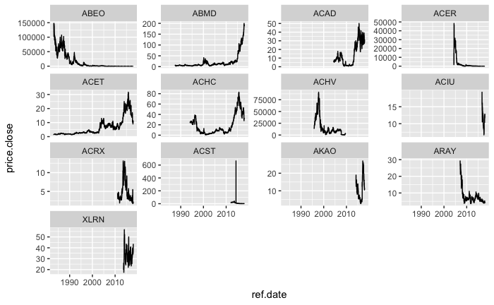

### Import S&P 500 value using

S&P Index ticker is SPY and began in January 29, 1993.

```
[1] "1993-01-29" "2019-05-24"
```

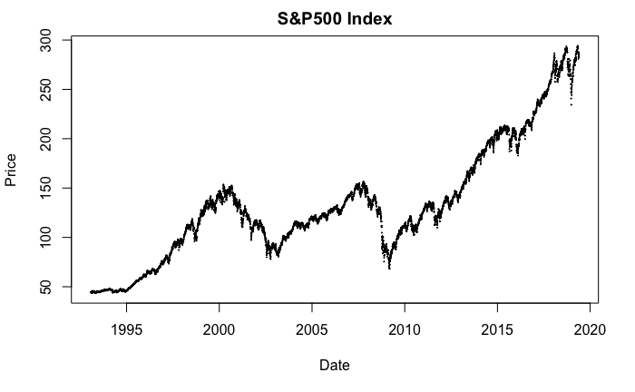

Also, it looks like I can download this as timeseries data (“ts”) getSymbols(‘F’,src=‘yahoo’,return.class=‘ts’)

### Import NYSE Biotech index

NYSE Arca Biotechnology index (BTK), stated in January 2003.

[output not shown]

```
[1] "2003-01-03" "2019-06-03"
```

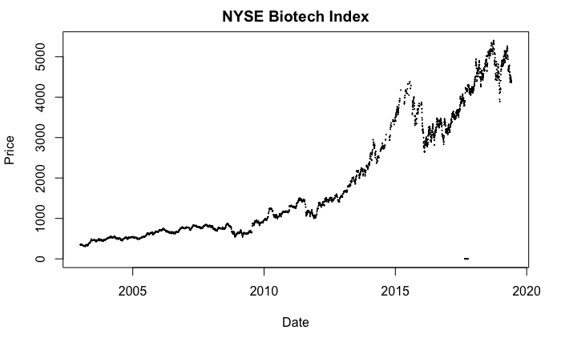

### Import Biotech index value

```
[1] "2003-12-12" "2019-05-24"
```

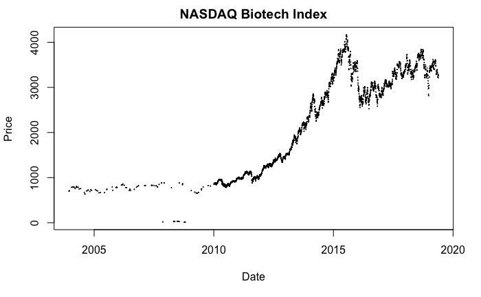

### Import JPM week dates

I couldn’t find a website where is listed the JPM weeks over the history of the conference. Based on some searches of the previous names of the conference (Hambrecht & Quist Healthcare Conference, Chase H & Q, now JP Morgan) it seems like it’s always early January:

- First JPM week, Hambrecht & Quist Healthcare Conference, was January 10-12, 1983. [https://wrhambrecht.com/wp-content/uploads/2015/02/LSFMagWinter-2015-page1.png]
- Genetech press release puts second JPM week on January 10, 1984.
- 2001: Puts it the week of Jan 12 [https://www.wired.com/2001/01/the-biotech-faves-for-2001/]
- 2018 was January 8 - 11 [https://www.jpmorgan.com/country/US/EN/jpmorgan/investbk/conferences/healthcare]

So I picked likely start dates in each year and then filled in the dates for the rest of the week.

[output not shown]

[output cut: 26 more lines]

```
  [1] "1983-01-09" "1984-01-08" "1985-01-06" "1986-01-05" "1987-01-11" "1988-01-10" "1989-01-08" "1990-01-07" "1991-01-06" "1992-01-05"
 [11] "1993-01-10" "1994-01-09" "1995-01-08" "1996-01-07" "1997-01-05" "1998-01-11" "1999-01-10" "2000-01-09" "2001-01-07" "2002-01-06"
 [21] "2003-01-05" "2004-01-11" "2005-01-09" "2006-01-08" "2007-01-07" "2008-01-06" "2009-01-11" "2010-01-10" "2011-01-09" "2012-01-08"
 [31] "2013-01-06" "2014-01-05" "2015-01-11" "2016-01-10" "2017-01-08" "2018-01-07" "1983-01-10" "1984-01-09" "1985-01-07" "1986-01-06"
 [41] "1987-01-12" "1988-01-11" "1989-01-09" "1990-01-08" "1991-01-07" "1992-01-06" "1993-01-11" "1994-01-10" "1995-01-09" "1996-01-08"
 [51] "1997-01-06" "1998-01-12" "1999-01-11" "2000-01-10" "2001-01-08" "2002-01-07" "2003-01-06" "2004-01-12" "2005-01-10" "2006-01-09"
 [61] "2007-01-08" "2008-01-07" "2009-01-12" "2010-01-11" "2011-01-10" "2012-01-09" "2013-01-07" "2014-01-06" "2015-01-12" "2016-01-11"
 [71] "2017-01-09" "2018-01-08" "1983-01-11" "1984-01-10" "1985-01-08" "1986-01-07" "1987-01-13" "1988-01-12" "1989-01-10" "1990-01-09"
 [81] "1991-01-08" "1992-01-07" "1993-01-12" "1994-01-11" "1995-01-10" "1996-01-09" "1997-01-07" "1998-01-13" "1999-01-12" "2000-01-11"
 [91] "2001-01-09" "2002-01-08" "2003-01-07" "2004-01-13" "2005-01-11" "2006-01-10" "2007-01-09" "2008-01-08" "2009-01-13" "2010-01-12"
[101] "2011-01-11" "2012-01-10" "2013-01-08" "2014-01-07" "2015-01-13" "2016-01-12" "2017-01-10" "2018-01-09" "1983-01-12" "1984-01-11"
[111] "1985-01-09" "1986-01-08" "1987-01-14" "1988-01-13" "1989-01-11" "1990-01-10" "1991-01-09" "1992-01-08" "1993-01-13" "1994-01-12"
[121] "1995-01-11" "1996-01-10" "1997-01-08" "1998-01-14" "1999-01-13" "2000-01-12" "2001-01-10" "2002-01-09" "2003-01-08" "2004-01-14"
[131] "2005-01-12" "2006-01-11" "2007-01-10" "2008-01-09" "2009-01-14" "2010-01-13" "2011-01-12" "2012-01-11" "2013-01-09" "2014-01-08"
[141] "2015-01-14" "2016-01-13" "2017-01-11" "2018-01-10" "1983-01-13" "1984-01-12" "1985-01-10" "1986-01-09" "1987-01-15" "1988-01-14"
[151] "1989-01-12" "1990-01-11" "1991-01-10" "1992-01-09" "1993-01-14" "1994-01-13" "1995-01-12" "1996-01-11" "1997-01-09" "1998-01-15"
[161] "1999-01-14" "2000-01-13" "2001-01-11" "2002-01-10" "2003-01-09" "2004-01-15" "2005-01-13" "2006-01-12" "2007-01-11" "2008-01-10"
[171] "2009-01-15" "2010-01-14" "2011-01-13" "2012-01-12" "2013-01-10" "2014-01-09" "2015-01-15" "2016-01-14" "2017-01-12" "2018-01-11"
```

## Analysis

Cleaning the data, some thoughts:

- I removed stock prices that are unbelievable high. I found that “The most expensive publicly traded stock of all time is Warren Buffett’s Berkshire Hathaway (BRK.A), which is trading at $305,500 per share, as of Oct. 23, 2018))” [https://www.investopedia.com/ask/answers/…/whats-most-expensive-stock-all-time.asp_] so I removed any prices that are higher than this value.
- I (above) removed companies duplicated between NYSE/NASDAQ. Were these duplications due to companies switching exhanges? Other issues?
- Other cleaning I could do: check that low prices are always < high prices, check for missing data, etc…
- A point on missing data: the BatchGetSymbols function does a lot to replace missing data with most recent prices. I could look into the impact of this default parameter on my analysis at a later time.

```
[1] 2014281      10
[1] 1991750      10
```

Looks like we got rid of some bad data. Plot some price.high by company over the dates.

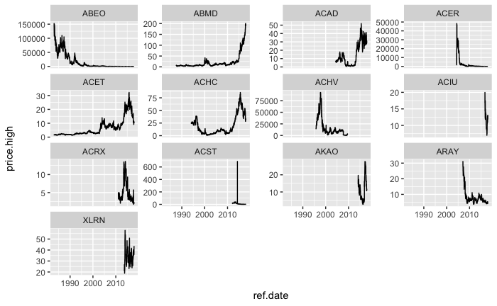

Looks good. These plots show that BatchGetSymbols() was able to handle companies as the entered and exited the stock market (unlike getSymbols()).

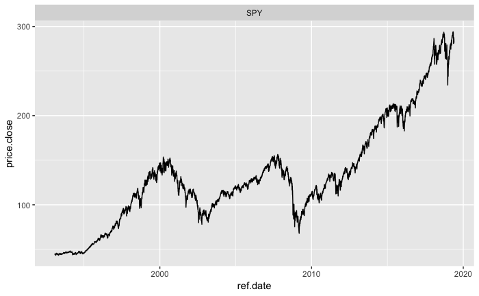

```r
ggplot(SP500_index_daily_stocks, aes(x = ref.date, y = price.close)) +
  geom_line() +
  facet_wrap(~ticker, scales = 'free_y')
```

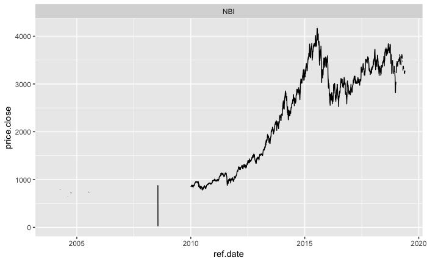

```r
ggplot(biotech_index_daily_stocks, aes(x = ref.date, y = price.close)) +
  geom_line() +
  facet_wrap(~ticker, scales = 'free_y')
```

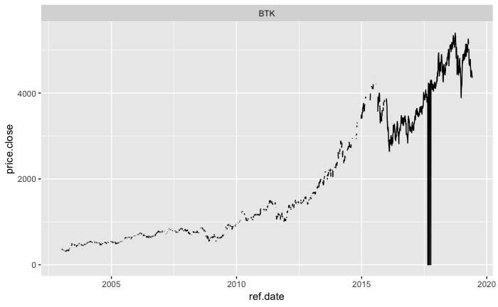

```r
ggplot(BTK_index_daily_stocks, aes(x = ref.date, y = price.close)) +
  geom_line() +
  facet_wrap(~ticker, scales = 'free_y')
```

Given how spotty the data is prior to 2010, let’s just use NBI 2010 and later:

```
[1] 3888    8
[1] 2364    8
```

Dropped a bunch of useless rows. Woo. Plot again:

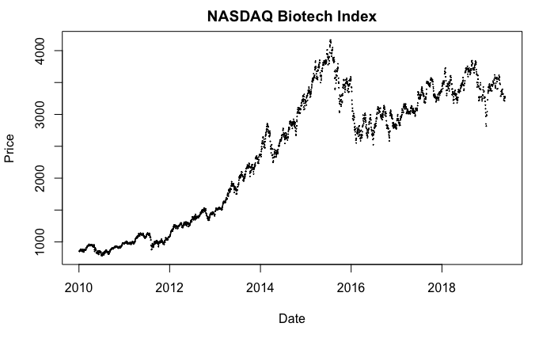

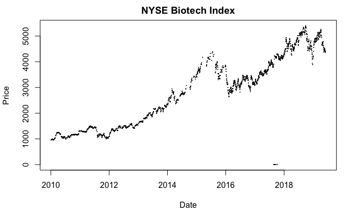

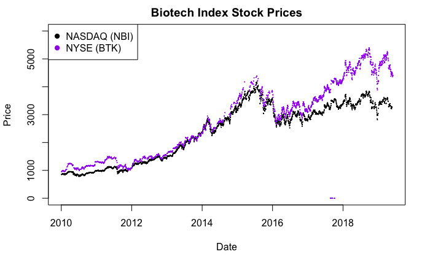

### Calculate stock price fluctuations

I’m using the word “fluctuations” here because I don’t have the technical expertise in finance to use a word like “volatility” which has a couple of specific definitions in finance. By “fluctuations” I mean that I’ll calculate the range in price for each stock each week of the year, then I’ll compare that range to the range over JPM week. This output will be a relative price range.

Calculate max net change (range) in price per day.

| price.high | price.low | ref.date | ticker | year | price_range |
| --- | --- | --- | --- | --- | --- |
| 142500 | 137500 | 1983-01-10 | ABEO | 1983 | 5000 |
| 140000 | 135000 | 1983-01-11 | ABEO | 1983 | 5000 |
| 137500 | 132500 | 1983-01-12 | ABEO | 1983 | 5000 |
| 132500 | 127500 | 1983-01-13 | ABEO | 1983 | 5000 |
| 80000 | 77500 | 1984-01-09 | ABEO | 1984 | 2500 |
| 75000 | 72500 | 1984-01-10 | ABEO | 1984 | 2500 |

```
    Min.  1st Qu.   Median     Mean  3rd Qu.     Max.
    0.00     0.19     0.50    40.87     1.31 86100.00
```

| price.high | price.low | ref.date | ticker | year | price_range |
| --- | --- | --- | --- | --- | --- |
| 869.38 | 869.38 | 2010-01-11 | NBI | 2010 | 0.000000 |
| 865.16 | 865.16 | 2010-01-12 | NBI | 2010 | 0.000000 |
| 877.30 | 877.30 | 2010-01-13 | NBI | 2010 | 0.000000 |
| 878.89 | 878.89 | 2010-01-14 | NBI | 2010 | 0.000000 |
| 988.52 | 980.56 | 2011-01-10 | NBI | 2011 | 7.960022 |
| 993.33 | 988.85 | 2011-01-11 | NBI | 2011 | 4.480041 |
| 997.27 | 988.62 | 2011-01-12 | NBI | 2011 | 8.650025 |
| 999.99 | 995.86 | 2011-01-13 | NBI | 2011 | 4.130005 |
| 1131.48 | 1121.09 | 2012-01-09 | NBI | 2012 | 10.390014 |
| 1152.12 | 1140.01 | 2012-01-10 | NBI | 2012 | 12.109985 |

[output cut: 26 more lines]

```
   Min. 1st Qu.  Median    Mean 3rd Qu.    Max.
   0.00    0.00    0.00    8.86   15.79   54.30
```

| price.high | price.low | ref.date | ticker | year | price_range |
| --- | --- | --- | --- | --- | --- |
| 986.24 | 986.24 | 2010-01-14 | BTK | 2010 | 0 |
| 1202.59 | 1202.59 | 2012-01-10 | BTK | 2012 | 0 |
| 1230.25 | 1230.25 | 2012-01-11 | BTK | 2012 | 0 |
| 1237.83 | 1237.83 | 2012-01-12 | BTK | 2012 | 0 |
| 1620.98 | 1620.98 | 2013-01-08 | BTK | 2013 | 0 |
| 2322.12 | 2322.12 | 2014-01-06 | BTK | 2014 | 0 |
| 2364.23 | 2364.23 | 2014-01-07 | BTK | 2014 | 0 |
| 2398.23 | 2398.23 | 2014-01-08 | BTK | 2014 | 0 |
| 3578.99 | 3578.99 | 2015-01-12 | BTK | 2015 | 0 |
| 3607.29 | 3607.29 | 2015-01-13 | BTK | 2015 | 0 |

[output cut: 14 more lines]

```
   Min. 1st Qu.  Median    Mean 3rd Qu.    Max.
      0       0       0       0       0       0
```

| price.high | price.low | ref.date | ticker | year | price_range |
| --- | --- | --- | --- | --- | --- |
| 47.5937 | 46.9687 | 1994-01-10 | SPY | 1994 | 0.625000 |
| 47.5625 | 47.3437 | 1994-01-11 | SPY | 1994 | 0.218800 |
| 47.5312 | 47.1875 | 1994-01-12 | SPY | 1994 | 0.343700 |
| 47.3125 | 47.1562 | 1994-01-13 | SPY | 1994 | 0.156300 |
| 46.0937 | 46.0000 | 1995-01-09 | SPY | 1995 | 0.093700 |
| 46.3906 | 46.1406 | 1995-01-10 | SPY | 1995 | 0.250000 |
| 46.2968 | 45.8125 | 1995-01-11 | SPY | 1995 | 0.484299 |
| 46.2187 | 46.0312 | 1995-01-12 | SPY | 1995 | 0.187500 |
| 61.9062 | 61.7343 | 1996-01-08 | SPY | 1996 | 0.171901 |
| 62.0625 | 60.6250 | 1996-01-09 | SPY | 1996 | 1.437500 |

[output cut: 90 more lines]

```
   Min. 1st Qu.  Median    Mean 3rd Qu.    Max.
 0.0937  0.8800  1.2400  1.6385  2.3376  6.4800
```

Calculate max price and min price each JPM week (by year) and list as the price_range.

| ticker | year | max_price | min_price | price_range |
| --- | --- | --- | --- | --- |
| ABBV | 2013 | 3.545000e+01 | 3.333000e+01 | 2.119999 |
| ABBV | 2014 | 5.270000e+01 | 4.987000e+01 | 2.830002 |
| ABBV | 2015 | 6.693000e+01 | 6.186000e+01 | 5.069999 |
| ABBV | 2016 | 5.683000e+01 | 5.071000e+01 | 6.120003 |
| ABBV | 2017 | 6.450000e+01 | 6.042000e+01 | 4.080002 |
| ABC | 1996 | 4.093750e+00 | 4.000000e+00 | 0.093750 |
| ABC | 1997 | 5.765625e+00 | 5.390625e+00 | 0.375000 |
| ABC | 1998 | 7.179688e+00 | 6.703125e+00 | 0.476563 |
| ABC | 1999 | 1.003125e+01 | 9.031250e+00 | 1.000000 |
| ABC | 2000 | 5.953125e+00 | 4.750000e+00 | 1.203125 |

[output cut: 990 more lines]

| ticker | year | max_price | min_price | price_range |
| --- | --- | --- | --- | --- |
| NBI | 2010 | 878.89 | 865.16 | 13.73004 |
| NBI | 2011 | 999.99 | 980.56 | 19.42999 |
| NBI | 2012 | 1167.51 | 1121.09 | 46.42004 |
| NBI | 2013 | 1532.97 | 1479.20 | 53.77002 |
| NBI | 2014 | 2455.41 | 2323.88 | 131.53003 |
| NBI | 2015 | 3300.38 | 3219.61 | 80.76978 |
| NBI | 2016 | 3097.40 | 2933.10 | 164.29980 |
| NBI | 2017 | 2996.73 | 2908.04 | 88.68994 |
| NBI | 2018 | 3499.79 | 3406.08 | 93.70996 |

| ticker | year | max_price | min_price | price_range |
| --- | --- | --- | --- | --- |
| BTK | 2010 | 986.24 | 986.24 | 0.00000 |
| BTK | 2012 | 1237.83 | 1202.59 | 35.23999 |
| BTK | 2013 | 1620.98 | 1620.98 | 0.00000 |
| BTK | 2014 | 2398.23 | 2322.12 | 76.10986 |
| BTK | 2015 | 3614.39 | 3542.85 | 71.53980 |
| BTK | 2016 | 3351.31 | 3173.57 | 177.73999 |
| BTK | 2017 | 3325.52 | 3208.40 | 117.12012 |
| BTK | 2018 | 4441.80 | 4283.21 | 158.58984 |

| ticker | year | max_price | min_price | price_range |
| --- | --- | --- | --- | --- |
| SPY | 1994 | 47.5937 | 46.9687 | 0.625000 |
| SPY | 1995 | 46.3906 | 45.8125 | 0.578098 |
| SPY | 1996 | 62.0625 | 59.6406 | 2.421902 |
| SPY | 1997 | 75.8750 | 74.1250 | 1.750000 |
| SPY | 1998 | 95.9687 | 90.9062 | 5.062500 |
| SPY | 1999 | 127.6875 | 120.3750 | 7.312500 |
| SPY | 2000 | 146.9062 | 142.8750 | 4.031204 |
| SPY | 2001 | 133.4843 | 127.6875 | 5.796799 |
| SPY | 2002 | 117.9900 | 115.3000 | 2.689995 |
| SPY | 2003 | 93.4900 | 91.0500 | 2.439995 |

[output cut: 15 more lines]

| ticker | year | week | max_price | min_price | price_range |
| --- | --- | --- | --- | --- | --- |
| ABBV | 2013 | 3 | 37.320000 | 33.709999 | 3.610001 |
| ABBV | 2013 | 4 | 38.520000 | 35.930000 | 2.590000 |
| ABBV | 2013 | 5 | 37.529999 | 36.250000 | 1.279999 |
| ABBV | 2013 | 6 | 37.730000 | 35.750000 | 1.980000 |
| ABBV | 2013 | 7 | 37.810001 | 35.009998 | 2.800003 |
| ABBV | 2013 | 8 | 39.130001 | 37.110001 | 2.020000 |
| ABBV | 2013 | 9 | 38.250000 | 36.400002 | 1.849998 |
| ABBV | 2013 | 10 | 38.570000 | 37.080002 | 1.489998 |
| ABBV | 2013 | 11 | 38.540001 | 36.860001 | 1.680000 |
| ABBV | 2013 | 12 | 39.520000 | 37.840000 | 1.680000 |

[output cut: 990 more lines]

| ticker | year | week | max_price | min_price | price_range |
| --- | --- | --- | --- | --- | --- |
| NBI | 2010 | 3 | 885.07 | 864.33 | 20.739990 |
| NBI | 2010 | 4 | 866.57 | 854.02 | 12.549987 |
| NBI | 2010 | 5 | 880.68 | 849.02 | 31.659973 |
| NBI | 2010 | 6 | 862.13 | 841.27 | 20.859985 |
| NBI | 2010 | 7 | 882.78 | 868.76 | 14.020019 |
| NBI | 2010 | 8 | 881.61 | 868.20 | 13.409973 |
| NBI | 2010 | 9 | 909.94 | 878.86 | 31.080017 |
| NBI | 2010 | 10 | 937.99 | 916.37 | 21.619995 |
| NBI | 2010 | 11 | 940.70 | 935.19 | 5.510010 |
| NBI | 2010 | 12 | 963.38 | 944.19 | 19.190003 |

[output cut: 465 more lines]

| ticker | year | week | max_price | min_price | price_range |
| --- | --- | --- | --- | --- | --- |
| BTK | 2010 | 3 | 996.69 | 991.950 | 4.739990 |
| BTK | 2010 | 4 | 973.86 | 959.170 | 14.690002 |
| BTK | 2010 | 5 | 973.26 | 964.340 | 8.919983 |
| BTK | 2010 | 6 | 972.17 | 960.690 | 11.479981 |
| BTK | 2010 | 7 | 1025.83 | 992.170 | 33.659973 |
| BTK | 2010 | 8 | 1034.46 | 1034.100 | 0.359985 |
| BTK | 2010 | 9 | 1126.52 | 1040.760 | 85.760010 |
| BTK | 2010 | 10 | 1233.59 | 1167.010 | 66.579956 |
| BTK | 2010 | 11 | 1222.17 | 1217.700 | 4.470093 |
| BTK | 2010 | 12 | 1250.99 | 1233.590 | 17.400024 |

[output cut: 439 more lines]

| ticker | year | week | max_price | min_price | price_range |
| --- | --- | --- | --- | --- | --- |
| SPY | 1993 | 5 | 45.0937 | 43.7500 | 1.343700 |
| SPY | 1993 | 6 | 45.1250 | 44.5312 | 0.593800 |
| SPY | 1993 | 7 | 44.8750 | 42.8125 | 2.062500 |
| SPY | 1993 | 8 | 44.3750 | 43.3437 | 1.031300 |
| SPY | 1993 | 9 | 45.1875 | 44.1875 | 1.000000 |
| SPY | 1993 | 10 | 45.8437 | 44.7187 | 1.125000 |
| SPY | 1993 | 11 | 45.5000 | 44.8125 | 0.687500 |
| SPY | 1993 | 12 | 45.2812 | 44.5625 | 0.718700 |
| SPY | 1993 | 13 | 45.4687 | 44.8750 | 0.593700 |
| SPY | 1993 | 14 | 44.6562 | 44.0625 | 0.593700 |

[output cut: 990 more lines]

Compare all other weeks to JPM week.  
I’ll start with just 2017 and ticker == ABBV to simplify things, then build back up to all tickers and years. ABBV is “AbbVie is an American publicly traded biopharmaceutical company founded in 2013. It originated as a spin-off of Abbott Laboratories.” [https://en.wikipedia.org/wiki/AbbVie_Inc.]

```
 [1] 0.2598031 0.5833335 0.5024507 0.2377452 0.4730390 0.2303928 0.4705875 0.8749986 0.3651954 0.2622548 0.2769599 0.3137248 0.6029406 0.4534316
[15] 0.7941168 0.3578430 0.5612725 0.5661755 0.4338226 0.4166657 0.7230401 0.4583338 0.6691163 0.3995089 0.3872532 0.4730390 0.8063724 1.3161766
[29] 0.3774510 0.4411770 0.4460782 0.7034298 0.8431373 2.7843106 1.3014712 0.6691163 1.9019586 0.5931365 0.7132359 1.8872550 2.6372541 1.0857818
[43] 1.2132359 0.6617636 0.6151965 1.0343117 0.9362738 1.0073527 0.4607834 0.4215687
```

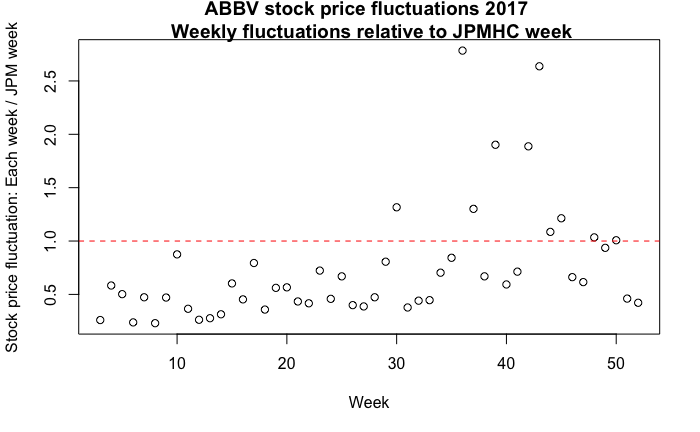

From this one example, we can see that the JPM week price range difference was not always greater than any other week of the year, but it was in the top 20% of weeks (10 points above red line implies 10 weeks had a price range >1x JPM week price range).  
Are there any years for ABBV for which the JPM week price range was the maximal range for the year?

```
         3     4     5     6     7    8    9   10   11    12   13    14    15    16    17    18   19    20    21    22    23    24    25    26
2013 FALSE FALSE  TRUE  TRUE FALSE TRUE TRUE TRUE TRUE  TRUE TRUE  TRUE FALSE FALSE FALSE FALSE TRUE FALSE FALSE FALSE  TRUE FALSE FALSE FALSE
2014  TRUE FALSE FALSE FALSE  TRUE TRUE TRUE TRUE TRUE FALSE TRUE FALSE FALSE  TRUE  TRUE  TRUE TRUE  TRUE  TRUE  TRUE FALSE  TRUE  TRUE FALSE
2015  TRUE  TRUE FALSE  TRUE  TRUE TRUE TRUE TRUE TRUE  TRUE TRUE  TRUE  TRUE  TRUE  TRUE  TRUE TRUE  TRUE  TRUE  TRUE  TRUE  TRUE  TRUE  TRUE
2016  TRUE  TRUE  TRUE  TRUE  TRUE TRUE TRUE TRUE TRUE  TRUE TRUE  TRUE  TRUE  TRUE  TRUE  TRUE TRUE  TRUE  TRUE  TRUE  TRUE  TRUE  TRUE  TRUE
2017  TRUE  TRUE  TRUE  TRUE  TRUE TRUE TRUE TRUE TRUE  TRUE TRUE  TRUE  TRUE  TRUE  TRUE  TRUE TRUE  TRUE  TRUE  TRUE  TRUE  TRUE  TRUE  TRUE
       27    28    29    30   31   32    33    34   35    36    37    38    39    40    41    42    43    44    45    46    47    48    49    50
2013 TRUE  TRUE  TRUE  TRUE TRUE TRUE FALSE  TRUE TRUE FALSE  TRUE FALSE FALSE FALSE FALSE FALSE FALSE FALSE  TRUE FALSE  TRUE  TRUE FALSE FALSE
2014 TRUE FALSE FALSE  TRUE TRUE TRUE  TRUE  TRUE TRUE  TRUE  TRUE FALSE  TRUE FALSE FALSE FALSE FALSE FALSE FALSE FALSE FALSE  TRUE FALSE FALSE
2015 TRUE  TRUE  TRUE  TRUE TRUE TRUE  TRUE FALSE TRUE  TRUE  TRUE  TRUE FALSE  TRUE  TRUE  TRUE FALSE FALSE  TRUE  TRUE  TRUE  TRUE  TRUE  TRUE
2016 TRUE  TRUE  TRUE  TRUE TRUE TRUE  TRUE  TRUE TRUE  TRUE  TRUE  TRUE  TRUE  TRUE  TRUE  TRUE  TRUE  TRUE FALSE  TRUE  TRUE  TRUE  TRUE  TRUE
2017 TRUE  TRUE  TRUE FALSE TRUE TRUE  TRUE  TRUE TRUE FALSE FALSE  TRUE FALSE  TRUE  TRUE FALSE FALSE FALSE FALSE  TRUE  TRUE FALSE  TRUE FALSE
        51   52   53
2013 FALSE TRUE TRUE
2014 FALSE TRUE TRUE
2015  TRUE TRUE TRUE
2016  TRUE TRUE TRUE
2017  TRUE TRUE   NA
```

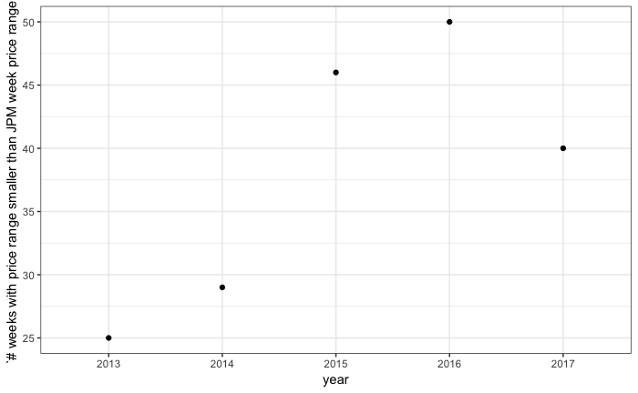

No, not quite. It was nearly the case in 2016.

Now, let’s extend this type of analysis to more tickers and also include a better summary visualization. I’ll create a table with years as rows, and then each ticker will be a column with the # weeks price range smaller than JPM week price range. We’ll be able to overlay all of these different tickers on the graph and we’ll look for trends.

The data is in “Wide” form right now, which is not very tidy! I’ll reshape into “Long” form for ease of compatibility with ggplot()

There are some zero values in this table that should really be NAs, so I’ll correct that now.

Plot the summary figure.

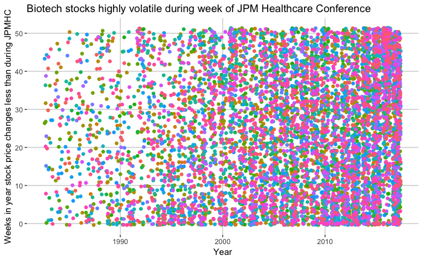

Yikes, that’s ugly and hard to interpret. Let’s try again.

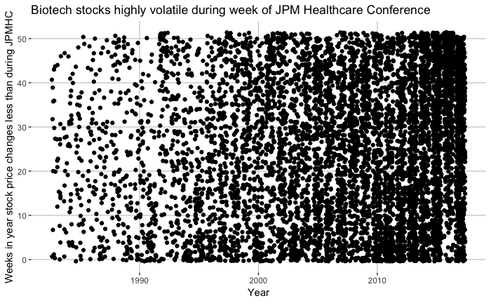

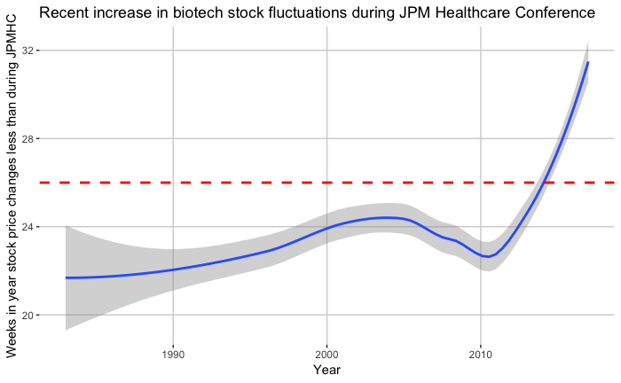

Let’s change week per year to a percentage of weeks to ease interpretation.

Plot percentages.

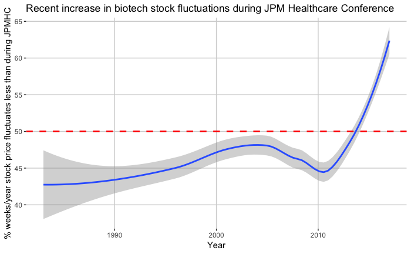

### Performance vs S&P 500

Let’s define performance as % increase from start to end of JPMHC week.

Change abline from no change to average weekly change that year.

### Hypothesis 2: 2. The biotech sector outperforms the S&P 500 during JPM week more often than is expected by chance.

#### S&P500 vs Biotech Index stock

Will need to limit analysis to 2010-2018 because those are the dates for which I have full years of both the biotech and s&P500 index information.

Calculate an empirical pvalue for each year: JPMHC week ratio >= other week ratios + 1 / # other weeks + 1 (JPM week)

```r
plot(c(2010, 2012:2016, 2018), BTK_pvals, ylim = c(0, 1), ylab = "P-value", xlab = "Date", pch = 19, main = "Biotech indices and S&P500 index stocks perform comparably\nduring JPMHC week vs later weeks in same year")
abline(h = 0.05, col = "red")
points(2010:2018, pvals, ylim = c(0, 1), ylab = "P-value", xlab = "Date", pch = 19, main = "NBI index and S&P500 index stocks perform comparably\nduring JPMHC week vs later weeks in the year", col = "blue")
legend("topright", legend = c("NYSE", "NASDAQ"), col = c("black", "blue"), pch = 19)
```

[output not shown]

What is might complicate the interpretation of the data:

- Beginning of a fiscal quarter? Control by look at other quarters?
- Every four years January means a new presidential term? Control by comparing years with and without inaugurations?
- The choice to use individual stocks (unweighted) in flucation analysis vs index stocks (with weighting) in performance analysis.
- Appropriate definition/calculation of fluctuation and performance.
- Not having a completely accurate list of JPMHC dates.

## Sources:

Helpful introductory tutorial to stock data in R by Curtis Miller: https://ntguardian.wordpress.com/2017/03/27/introduction-stock-market-data-r-1/

Example of how GetBatchSymbols works and improves upon quantmod library by Marcelo Perlin: https://cran.r-project.org/web/packages/BatchGetSymbols/vignettes/BatchGetSymbols-vignette.html